# Project: Investigate Movie data set from Tmdb

Note: The movie dataset for this reprt was taken from Kaggle  
https://www.kaggle.com/tmdb/tmdb-movie-metadata

- Introduction
- Data Wrangling
- Exploratory Data Analysis
- Conclusions

## 1. Introduction

1. id,imdb_id - index or row number of the movie
2. popularity -
3. budget,revenue - budget and revenue in Dollars
4. revenue
5. original_title,cast,homepage - Title of the movie, casts in the movie,website of the movie
6. director - Director of the movie
7. tagline,keywords - Few words of the movie, keywords separated with |
8. overview,runtime - words describing hte plot, runime in minutes
9. genres,production_companies - Genres of the movie separated with |, production companies separated with |
10. release_date,release_year - Column for release date and release year
11. vote_count,vote_average - total count of the votes, average of the overall votes
12. budget_adj,revenue_adj

### Some questions to answer

1. Which genres are most popular from year to year?
2. What kinds of properties are associated with movies that have high revenues?
3. Does the genres and the run time give a better vote average?

### Dependent and Independent variable

- Independent variables-
  1. The runtime
  2. release year,month
  3. genres -
- Dependent variable -
  1. vote average - is dependent on vote count
  2. revenue - dependent on many factors such as casts
  3. popularity -

```python
#importing packages pandas, numpy and matplotlib
import pandas as pd
import numpy as np
import matplotlib.pyplot as plt
import seaborn as sb
%matplotlib inline
#   http://ipython.readthedocs.io/en/stable/interactive/magics.html
movies_df = pd.read_csv('tmdb-movies.csv')
movies_df.head(3)
```

|  | id | imdb_id | popularity | budget | revenue | original_title | cast | homepage | director | tagline | ... | overview | runtime | genres | production_companies | release_date | vote_count | vote_average | release_year | budget_adj | revenue_adj |
| --- | --- | --- | --- | --- | --- | --- | --- | --- | --- | --- | --- | --- | --- | --- | --- | --- | --- | --- | --- | --- | --- |
| 0 | 135397 | tt0369610 | 32.985763 | 150000000 | 1513528810 | Jurassic World | Chris Pratt\|Bryce Dallas Howard\|Irrfan Khan\|Vi... | http://www.jurassicworld.com/ | Colin Trevorrow | The park is open. | ... | Twenty-two years after the events of Jurassic ... | 124 | Action\|Adventure\|Science Fiction\|Thriller | Universal Studios\|Amblin Entertainment\|Legenda... | 6/9/15 | 5562 | 6.5 | 2015 | 1.379999e+08 | 1.392446e+09 |
| 1 | 76341 | tt1392190 | 28.419936 | 150000000 | 378436354 | Mad Max: Fury Road | Tom Hardy\|Charlize Theron\|Hugh Keays-Byrne\|Nic... | http://www.madmaxmovie.com/ | George Miller | What a Lovely Day. | ... | An apocalyptic story set in the furthest reach... | 120 | Action\|Adventure\|Science Fiction\|Thriller | Village Roadshow Pictures\|Kennedy Miller Produ... | 5/13/15 | 6185 | 7.1 | 2015 | 1.379999e+08 | 3.481613e+08 |
| 2 | 262500 | tt2908446 | 13.112507 | 110000000 | 295238201 | Insurgent | Shailene Woodley\|Theo James\|Kate Winslet\|Ansel... | http://www.thedivergentseries.movie/#insurgent | Robert Schwentke | One Choice Can Destroy You | ... | Beatrice Prior must confront her inner demons ... | 119 | Adventure\|Science Fiction\|Thriller | Summit Entertainment\|Mandeville Films\|Red Wago... | 3/18/15 | 2480 | 6.3 | 2015 | 1.012000e+08 | 2.716190e+08 |

3 rows × 21 columns

## 2. Data Wrangling

- Assessing Data
- Cleaning Data
- Appending

### 2.1 Assessing Data

1. Number of samples in the datasetand features of the columns
2. Features with missing values
3. Duplicate rows in the dataset
4. Statistical data of the dataset
5. Introspect columns

From scrolling the excel sheet we see many values are having 0 which is in the string format. this can be changed to Null.

#### 1. Number of samples in dataset and features of the columns

```python
movies_df.shape
```

```
(10866, 21)
```

The number of rows and column in the csv file is **10866** and **21**

```python
movies_df.info()
```

```
<class 'pandas.core.frame.DataFrame'>
RangeIndex: 10866 entries, 0 to 10865
Data columns (total 21 columns):
id                      10866 non-null int64
imdb_id                 10856 non-null object
popularity              10866 non-null float64
budget                  10866 non-null int64
revenue                 10866 non-null int64
original_title          10866 non-null object
cast                    10790 non-null object
homepage                2936 non-null object
director                10822 non-null object
tagline                 8042 non-null object
keywords                9373 non-null object
overview                10862 non-null object
runtime                 10866 non-null int64
genres                  10843 non-null object
production_companies    9836 non-null object
release_date            10866 non-null object
vote_count              10866 non-null int64
vote_average            10866 non-null float64
release_year            10866 non-null int64
budget_adj              10866 non-null float64
revenue_adj             10866 non-null float64
dtypes: float64(4), int64(6), object(11)
memory usage: 1.7+ MB
```

##### From the 'info()' function we find out:

- the **release date** is in form of an **object**
- All the column names are in small letter and separated with '_'
- columns which don't seem to be required to carry out statistical and inferencial
  - id,imdb_id
  - overview, tag line,home page
  - definition of budget_adj,revenue_adj is not clear

#### 2. Featues with missing values

```python
movies_df.isnull().sum()
```

```
id                         0
imdb_id                   10
popularity                 0
budget                     0
revenue                    0
original_title             0
cast                      76
homepage                7930
director                  44
tagline                 2824
keywords                1493
overview                   4
runtime                    0
genres                    23
production_companies    1030
release_date               0
vote_count                 0
vote_average               0
release_year               0
budget_adj                 0
revenue_adj                0
dtype: int64
```

#### 3. Number of duplicated rows

```python
movies_df.duplicated().sum()
```

```
1
```

The number of duplicate rows is 1

#### 4. statistical data

Summary statistics

```python
movies_df.describe()
```

|  | id | popularity | budget | revenue | runtime | vote_count | vote_average | release_year | budget_adj | revenue_adj |
| --- | --- | --- | --- | --- | --- | --- | --- | --- | --- | --- |
| count | 10866.000000 | 10866.000000 | 1.086600e+04 | 1.086600e+04 | 10866.000000 | 10866.000000 | 10866.000000 | 10866.000000 | 1.086600e+04 | 1.086600e+04 |
| mean | 66064.177434 | 0.646441 | 1.462570e+07 | 3.982332e+07 | 102.070863 | 217.389748 | 5.974922 | 2001.322658 | 1.755104e+07 | 5.136436e+07 |
| std | 92130.136561 | 1.000185 | 3.091321e+07 | 1.170035e+08 | 31.381405 | 575.619058 | 0.935142 | 12.812941 | 3.430616e+07 | 1.446325e+08 |
| min | 5.000000 | 0.000065 | 0.000000e+00 | 0.000000e+00 | 0.000000 | 10.000000 | 1.500000 | 1960.000000 | 0.000000e+00 | 0.000000e+00 |
| 25% | 10596.250000 | 0.207583 | 0.000000e+00 | 0.000000e+00 | 90.000000 | 17.000000 | 5.400000 | 1995.000000 | 0.000000e+00 | 0.000000e+00 |
| 50% | 20669.000000 | 0.383856 | 0.000000e+00 | 0.000000e+00 | 99.000000 | 38.000000 | 6.000000 | 2006.000000 | 0.000000e+00 | 0.000000e+00 |
| 75% | 75610.000000 | 0.713817 | 1.500000e+07 | 2.400000e+07 | 111.000000 | 145.750000 | 6.600000 | 2011.000000 | 2.085325e+07 | 3.369710e+07 |
| max | 417859.000000 | 32.985763 | 4.250000e+08 | 2.781506e+09 | 900.000000 | 9767.000000 | 9.200000 | 2015.000000 | 4.250000e+08 | 2.827124e+09 |

```python
movies_df.corr()
```

|  | id | popularity | budget | revenue | runtime | vote_count | vote_average | release_year | budget_adj | revenue_adj |
| --- | --- | --- | --- | --- | --- | --- | --- | --- | --- | --- |
| id | 1.000000 | -0.014350 | -0.141351 | -0.099227 | -0.088360 | -0.035551 | -0.058363 | 0.511364 | -0.189015 | -0.138477 |
| popularity | -0.014350 | 1.000000 | 0.545472 | 0.663358 | 0.139033 | 0.800828 | 0.209511 | 0.089801 | 0.513550 | 0.609083 |
| budget | -0.141351 | 0.545472 | 1.000000 | 0.734901 | 0.191283 | 0.632702 | 0.081014 | 0.115931 | 0.968963 | 0.622505 |
| revenue | -0.099227 | 0.663358 | 0.734901 | 1.000000 | 0.162838 | 0.791175 | 0.172564 | 0.057048 | 0.706427 | 0.919110 |
| runtime | -0.088360 | 0.139033 | 0.191283 | 0.162838 | 1.000000 | 0.163278 | 0.156835 | -0.117204 | 0.221114 | 0.175676 |
| vote_count | -0.035551 | 0.800828 | 0.632702 | 0.791175 | 0.163278 | 1.000000 | 0.253823 | 0.107948 | 0.587051 | 0.707942 |
| vote_average | -0.058363 | 0.209511 | 0.081014 | 0.172564 | 0.156835 | 0.253823 | 1.000000 | -0.117632 | 0.093039 | 0.193085 |
| release_year | 0.511364 | 0.089801 | 0.115931 | 0.057048 | -0.117204 | 0.107948 | -0.117632 | 1.000000 | 0.016793 | -0.066256 |
| budget_adj | -0.189015 | 0.513550 | 0.968963 | 0.706427 | 0.221114 | 0.587051 | 0.093039 | 0.016793 | 1.000000 | 0.646607 |
| revenue_adj | -0.138477 | 0.609083 | 0.622505 | 0.919110 | 0.175676 | 0.707942 | 0.193085 | -0.066256 | 0.646607 | 1.000000 |

We can see a strong co reletion between vote count and popularity 0.8  
budget_adj,revenue_adj are strongly co related with budget, revenue  
there is some co relation of budget and reneue 0.73  
revenue and vote count shows a strong co relation of .79

#### 5. Introspecting columns

```python
movies_df[['genres','keywords','cast','director','production_companies']].head()
```

|  | genres | keywords | cast | director | production_companies |
| --- | --- | --- | --- | --- | --- |
| 0 | Action\|Adventure\|Science Fiction\|Thriller | monster\|dna\|tyrannosaurus rex\|velociraptor\|island | Chris Pratt\|Bryce Dallas Howard\|Irrfan Khan\|Vi... | Colin Trevorrow | Universal Studios\|Amblin Entertainment\|Legenda... |
| 1 | Action\|Adventure\|Science Fiction\|Thriller | future\|chase\|post-apocalyptic\|dystopia\|australia | Tom Hardy\|Charlize Theron\|Hugh Keays-Byrne\|Nic... | George Miller | Village Roadshow Pictures\|Kennedy Miller Produ... |
| 2 | Adventure\|Science Fiction\|Thriller | based on novel\|revolution\|dystopia\|sequel\|dyst... | Shailene Woodley\|Theo James\|Kate Winslet\|Ansel... | Robert Schwentke | Summit Entertainment\|Mandeville Films\|Red Wago... |
| 3 | Action\|Adventure\|Science Fiction\|Fantasy | android\|spaceship\|jedi\|space opera\|3d | Harrison Ford\|Mark Hamill\|Carrie Fisher\|Adam D... | J.J. Abrams | Lucasfilm\|Truenorth Productions\|Bad Robot |
| 4 | Action\|Crime\|Thriller | car race\|speed\|revenge\|suspense\|car | Vin Diesel\|Paul Walker\|Jason Statham\|Michelle ... | James Wan | Universal Pictures\|Original Film\|Media Rights ... |

The keywords,genres,cast and production_companies are separated with |, with more than one keywords,genres,actor and production_companies for a single movie

#### Task:

Based on the assessing

1. Changing release_date the type of the column release_date to Datte format
2. Removing columns id,imbd_id,overview,tagline, homepage,budget_adj,revenue_adj
3. Dropping duplicates

#### 1. Changing release_date type to Date Format

```python
#converting moive release date from object to date format
movies_df['release_date'] = pd.to_datetime(movies_df['release_date'])
```

#### 2. Dropping unwanted columns

##### movie id

reason:No statistical desicions can be made

##### original Title

reason: since we are going to be doing descriptive stats on 10,000 rows individual titles w=can be neglected

##### imbd_id

Reason:No statistical desicions can be made

##### tagline

Reason: we have a column for keywords, tagline will give least amount information which the keywords can provide

##### Homepage

Reason: idividual homepage can not help in any descriptive or inferential statistics in this case

##### budget_adj, revenue_adj

Reason: clear definiion is not known

```python
#droping unwanted columns
movies_df.drop(['id','original_title','imdb_id','overview','tagline','homepage','budget_adj','revenue_adj'], axis=1,inplace=True)
```

#### 3. replaceing 0 with NaN (Many revenue and bus=dget are zero which is a NaN value, so to calculate missing budget and revenue replacing 0 with NaN)

```python
#replace int 0 with null in the dataframe
movies_df.replace(0,np.NaN,inplace = True)
```

```python
movies_df.isnull().sum()
```

```
popularity                 0
budget                  5696
revenue                 6016
cast                      76
director                  44
keywords                1493
runtime                   31
genres                    23
production_companies    1030
release_date               0
vote_count                 0
vote_average               0
release_year               0
dtype: int64
```

```python
movies_df.drop_duplicates(inplace=True)
```

### 3.Appending Data

1. Making new DataFrame movies_gen which drops 23 rows which do not have genres  
   -Making new columns release_month
2. Dataframe or pandas series for keywords,popularity,cast,production comapnies and genres
3. duplicate rows in the dataset
4. statistical data of the dataset
5. introspect columns

#### 1.Making new Dataframe for genres,only 23 genres are missing hence we can drop it because we cannot fill the Null values with any statistical approach

```python
movies_gen = movies_df.dropna(subset = ['genres'])
movies_df['release_month'] = movies_df['release_date'].dt.month
```

#### 2. collecting genres with years

droping rows with no genres and storing it in movies_gen

```python
#storing maximum year in data bases and minimum year of release in database
year_max = movies_gen['release_year'].max()
year_min = movies_gen['release_year'].min()
```

## 2.3Exploratory Data Analysis

### Is Vote Average co - related with

#### 1. Genre of the movie?

#### 2. Month it is released in?

#### 3. Runtime of the movie?

## 1. Is vote average related with genres of the movie?

##### 1. Finding unique genres in the database 2. Making Databases df_gen_count and df_gen_avg with unique genres as index and years in database as columns to count the number of genres separated with | for each movie.

###### 1. genre_uniq contains the unique set of genres in the database

```python
#genre_uniq contains the list of  genres unique in the data set
genre_list = list(movies_gen['genres'])
genre_uniq = []
for genres in genre_list:
    genres_sep = list(str(genres).split('|'))
    for gen in genres_sep:
        if gen not in genre_uniq:
            genre_uniq.append(gen)
print(genre_uniq)
```

```
['Action', 'Adventure', 'Science Fiction', 'Thriller', 'Fantasy', 'Crime', 'Western', 'Drama', 'Family', 'Animation', 'Comedy', 'Mystery', 'Romance', 'War', 'History', 'Music', 'Horror', 'Documentary', 'TV Movie', 'Foreign']
```

- genre_year_avg_zip contains list of zip genres,release_year and vote average values

```python
genre_year_avg_zip = list(zip(movies_gen['genres'],movies_gen['release_year'],movies_gen['vote_average']))
```

##### 2. Making Databases df_gen_count and df_gen_avg

```python
df_gen_count = pd.DataFrame(data = np.zeros((20,56)), index = genre_uniq, columns = (range(1960,2016,1)))
df_gen_count
df_gen_avg =  pd.DataFrame(data = np.zeros((20,56)), index = genre_uniq, columns = (range(1960,2016,1)))
df_gen_avg
for genres, year, avg in genre_year_avg_zip:
    #print(genres, year, avg)
    genres_sep = list(str(genres).split('|'))
    #print(genres_sep)
    for genre in genres_sep:
        df_gen_count.loc[genre][year] = df_gen_count.loc[genre][year] + 1
        df_gen_avg.loc[genre][year] = df_gen_avg.loc[genre][year] + avg
df_gen_count
df_gen_avg = df_gen_avg/df_gen_count
df_gen_avg.fillna(5, inplace=True)
df_gen_count.head(3)
```

|  | 1960 | 1961 | 1962 | 1963 | 1964 | 1965 | 1966 | 1967 | 1968 | 1969 | ... | 2006 | 2007 | 2008 | 2009 | 2010 | 2011 | 2012 | 2013 | 2014 | 2015 |
| --- | --- | --- | --- | --- | --- | --- | --- | --- | --- | --- | --- | --- | --- | --- | --- | --- | --- | --- | --- | --- | --- |
| Action | 8.0 | 7.0 | 8.0 | 4.0 | 5.0 | 9.0 | 14.0 | 7.0 | 6.0 | 10.0 | ... | 80.0 | 95.0 | 99.0 | 108.0 | 107.0 | 115.0 | 99.0 | 121.0 | 129.0 | 107.0 |
| Adventure | 5.0 | 6.0 | 7.0 | 7.0 | 5.0 | 6.0 | 11.0 | 7.0 | 5.0 | 5.0 | ... | 55.0 | 60.0 | 63.0 | 72.0 | 59.0 | 62.0 | 50.0 | 67.0 | 67.0 | 69.0 |
| Science Fiction | 3.0 | 4.0 | 2.0 | 2.0 | 4.0 | 2.0 | 6.0 | 4.0 | 4.0 | 3.0 | ... | 30.0 | 41.0 | 52.0 | 71.0 | 45.0 | 56.0 | 54.0 | 61.0 | 62.0 | 86.0 |

3 rows × 56 columns

**function df_sep** the function df_sep takes in two database of count and average and returns a list of genres counts, averages for years as provided in the function. For eg df_gen_count,df_gen_avg,1961,2015,11) will send back list of averages, count with years separated with 11 years i.e averages and counts on genres for the years 1961 - 1971, 1972 - 1982 so on till 2005 - 2015.

```python
def df_sep(df_gen_count,df_gen_avg,start,end,n):
    num = (end - start)//n + 1
    #print(num)
    labels,list_gen_count_sep,list_gen_avg_sep = ([] for i in range(3))
    df_gen_count_sep = pd.DataFrame()
    df_gen_avg_sep = pd.DataFrame()
    #print(years)
    if n == 1:
        #when n = 1, the years is continuos hence appending directily in the list
        #print("in 1" )
        for year in range(start,end+1):
            labels.append(str(year))
            list_gen_count_sep.append(list(df_gen_count[year]))
            list_gen_avg_sep.append(list(df_gen_avg[year]))
    else:
        #print("in n" )
        # when n is more than 1 creating new database with columns eg. 1961 - 1971 to 2005 - 2015
        df_gen_count_sep= pd.DataFrame(data = np.zeros((20,num)),index = genre_uniq,columns = (range(start,end,n)))
        df_gen_avg_sep = pd.DataFrame(data = np.zeros((20,num)),index = genre_uniq,columns = (range(start,end,n)))
        #Function to add the n years average and count in the new database column
        for year in range(start,end,n):
            labels.append(str(year)+"-"+str(year+n-1))
            for years in range(year,year+n):
                #print(years)
                df_gen_count_sep[year] = df_gen_count_sep[year] + df_gen_count[years]
                df_gen_avg_sep[year] = df_gen_avg_sep[year] + df_gen_avg[years]
            #appending columns of database in list which can be used for ploting graphs
            list_gen_count_sep.append(list(df_gen_count_sep[year]))
            list_gen_avg_sep.append(np.array(df_gen_avg_sep[year])/n)

    return(list_gen_count_sep,list_gen_avg_sep,labels)
```

##### df_sep(df_gen_count,df_gen_avg,1961,2015,11)

To check the average and counts at 11 years of intervals.  
Plotting the graph of an average multiplied two times to see the average in terms of 20 to visualise more clearly.

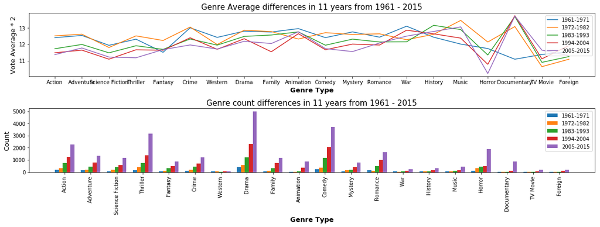

```python
#https://stackoverflow.com/questions/34162443/why-do-many-examples-use-fig-ax-plt-subplots-in-matplotlib-pyplot-python
list_gen_count_sep,list_gen_avg_sep,labels = df_sep(df_gen_count,df_gen_avg,1961,2015,11)
#https://matplotlib.org/examples/pylab_examples/subplots_demo.html
fig, [ax1,ax2] = plt.subplots(nrows=2, ncols=1,figsize=(16,6),constrained_layout=True)
for i in range(len(list_gen_count_sep)):
    #
    ax1.plot(genre_uniq,np.array(list_gen_avg_sep[i])*2),ax1.set_title('Genre Average differences in 11 years from 1961 - 2015',fontsize=15)
    ax2.set_title('Genre count differences in 11 years from 1961 - 2015',fontsize=15)
    ax2.bar(np.array(range(1,21,1)) + 0.15*(i-2),np.array(list_gen_count_sep[i])*2, width = 0.15)
ax1.legend(labels),ax2.legend(labels),ax1.set_ylabel('Vote Average * 2',fontsize=13),ax1.set_xlabel('Genre Type',fontweight='bold',fontsize=13),ax2.set_ylabel('Count',fontsize=13),ax2.set_xlabel('Genre Type',fontweight='bold',fontsize=13)
ax2.set_xticks(range(1,21,1)),ax2.set_xticklabels(genre_uniq)

plt.xticks(rotation=90)
plt.show()
```

**Average plot:**

- Horror movie average can be seen dipping over the years. since last decades the count of horror movies have increased
- documentry movies average didn't do well in 1961 - 1971, where as it can be seen it has been consistent and had the highest averages in next 5 decades.
- Crime's average can be seen dipping which is minimum in 2005 - 2015. There is static increase in the count of crime movies.

**Bar Graph:**

- From the 1961 - 2015 we can see the increase in number of **Drama and Comedy** movies over the years.
- From 1961 - 2015 bar graph we can see a trend in **Thriller movies** and also in last decade 2006 - 2015 the number of horror movies have increased significatly
- From the bar graph 1961 - 2015 we can see significant count increase in **horror movies and Documentry movies** from previous decades

##### Looking for Trends for genres averages and counts for the years 2011- 2015 and 2006,2010

[figure not shown]

```python
list_gen_count_sep2,list_gen_avg_sep2,labels2 = df_sep(df_gen_count,df_gen_avg,2011,2015,1)
list_gen_count_sep3,list_gen_avg_sep3,labels3 = df_sep(df_gen_count,df_gen_avg,2006,2010,1)
fig, [ax3,ax4,ax5,ax6] = plt.subplots(nrows=4, ncols=1,figsize=(16,14),constrained_layout=True)
for i in range(len(list_gen_count_sep)):
    ax3.plot(genre_uniq,np.array(list_gen_avg_sep2[i])*2),ax3.set_title('Genre Average differences in  years 2011 - 2015',fontsize=16)
    ax4.bar(np.array(range(1,21,1)) + 0.15*(i-2),np.array(list_gen_count_sep2[i])*2, width = 0.15)
    ax5.plot(genre_uniq,np.array(list_gen_avg_sep3[i])*2),ax5.set_title('Genre Average differences in years 2006 - 2010',fontsize=16)
    ax6.bar(np.array(range(1,21,1)) + 0.15*(i-2),np.array(list_gen_count_sep3[i])*2, width = 0.15)
ax4.set_title('Genre Count differences in  years 2011 - 2015',fontsize=16)
ax6.set_title('Genre Count differences in  years 2011 - 2015',fontsize=16)
ax3.legend(labels2),ax3.set_ylabel('Vote Average * 2',fontweight='bold'),ax3.set_xlabel('Genre Type',fontweight='bold',fontsize=13)
ax4.legend(labels2),ax4.set_ylabel('Count',fontweight='bold'),ax4.set_xlabel('Genre Type',fontweight='bold',fontsize=13)
ax5.legend(labels3),ax5.set_ylabel('Vote Average * 2',fontweight='bold'),ax5.set_xlabel('Genre Type',fontweight='bold',fontsize=13)
ax6.legend(labels3),ax6.set_ylabel('Count',fontweight='bold'),ax6.set_xlabel('Genre Type',fontweight='bold',fontsize=13)
ax4.set_xticks(range(1,21,1)),ax4.set_xticklabels(genre_uniq)
ax6.set_xticks(range(1,21,1)),ax6.set_xticklabels(genre_uniq)
plt.xticks(rotation=90)
plt.show()
```

## 2. Vote average corelated with release month?

```
(Text(0,0.5,'Count'), Text(0,0.5,'count'))
```

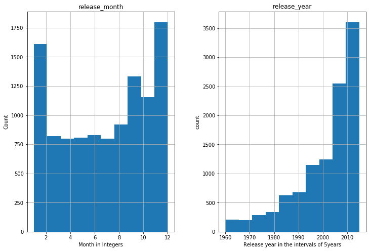

```python
#https://stackoverflow.com/questions/42832675/setting-axis-labels-for-histogram-pandas?rq=1
axarr = movies_df[["release_month","release_year"]].hist(figsize = (12,8))
ax1, ax2 = axarr.flatten()
ax1.set_xlabel('Month in Integers'),ax2.set_xlabel('Release year in the intervals of 5years')
ax1.set_ylabel('Count'),ax2.set_ylabel('count')
```

**function: gap_mon_5(pf,start,end,n)** sends list of vote averages for all the months for n intervals of years (movies_df,1961,2015,5) vote averages for all the months for the years 1961 - 1965... to 2011 - 2015

```python
list_mon2,list_average2,labels = ([] for i in range(3))
def gap_mon_5(pf,start,end,n):
    pf_5 = pd.DataFrame()
    pf_mean = pd.DataFrame()
    list_mon,list_average,labels = ([] for i in range(3))
    #genre_uniq_sorted = sorted(genre_uniq)
    for i in range(start,end,n):
        pf_5 = pf[(pf.release_year >= i) & (pf.release_year < i + n)]
        #group by mean and save it in temporary DataFrame
        pf_mean = pf_5.groupby(['release_month'],as_index = False)['vote_average'].mean()
        #print(pf_mean)
        #append dataframe column in the list
        list_mon.append(list(pf_mean['release_month'])),list_average.append(list(pf_mean['vote_average']))
        #drop columns to save averages for next set of years
        labels.append(str(i) + "-" + str(i + 5))
        pf_5.drop(["release_year", "release_month","vote_average"], axis = 1, inplace = True),pf_mean.drop(["release_month", "vote_average"], axis = 1, inplace = True)
    return(list_mon,list_average,labels)
```

**Plotting bar graph for vote averages for different months over the interval of 5 years from 1961 - 2015**

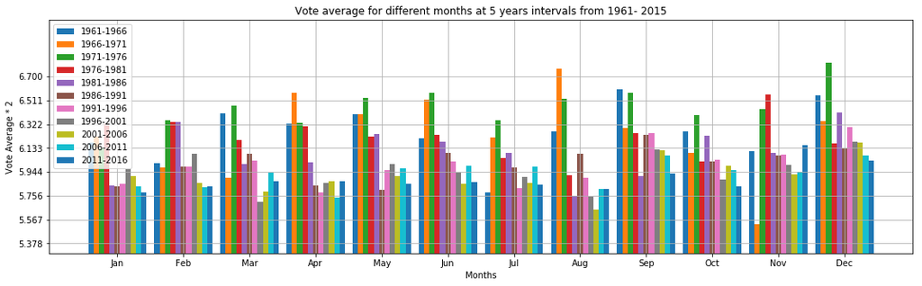

```
((5.3, 7.151666666666667), None, None)
```

```python
#list storing the months
months = ['Jan','Feb','Mar','Apr','May','Jun','Jul','Aug','Sep','Oct','Nov','Dec']
list_mon2,list_average2,labels = gap_mon_5(movies_df,1961,2015,5)
fig, ax1 = plt.subplots(nrows=1, ncols=1,figsize=(18,5),sharey= True)
for i in range(11):
    ax1.bar(np.array(list_mon2[i]) + 0.08*(i-5) ,list_average2[i],width = 0.08)
ax1.set_xticks([p   for p in range(1,13,1)]),plt.yticks(np.linspace(5, 6.7, 10))
#https://matplotlib.org/api/_as_gen/matplotlib.pyplot.ylim.html
ax1.legend(labels),ax1.set_ylabel('Vote Average * 2'),ax1.set_xlabel('Months')
ax1.set_title('Vote average for different months at 5 years intervals from 1961- 2015')
#replacing months numeric value with string
ax1.set_xticklabels(months)
plt.ylim(bottom=5.3),plt.grid(),plt.show()
```

- The vote averages for the years 2006 - 2016 have dipped compared to earlier years
- November vote average for the year 1966 - 1971 is below 5.5
- Dec of years 1971-1971 vote averages and Aug of 1966 - 1971 has vote averages above 6.7

##### using scatterplot to view the vote average data in another perspective

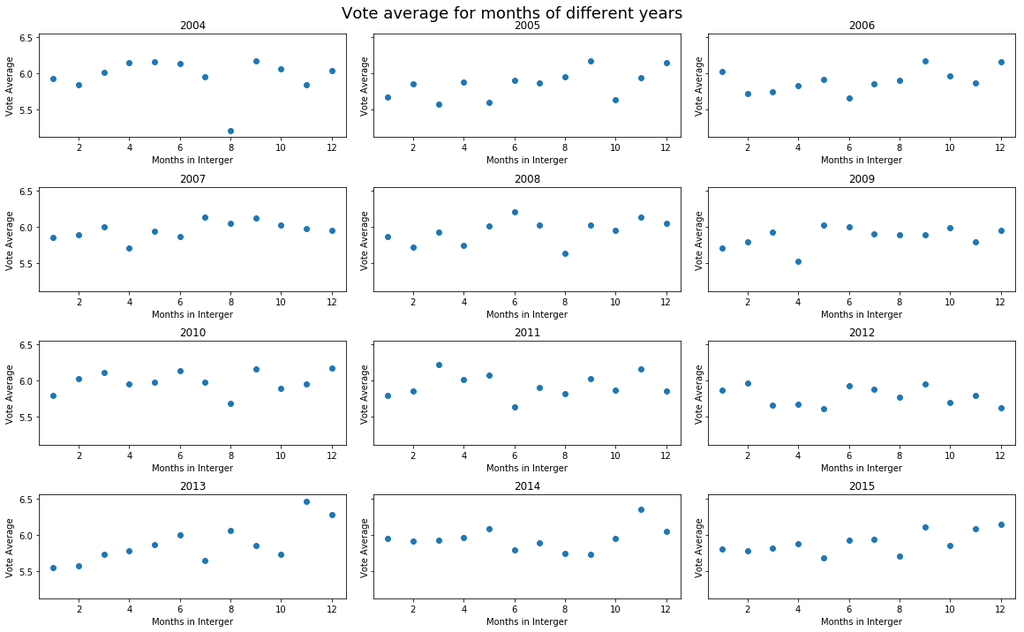

```python
list_mon3,list_average3,labels2 = gap_mon_5(movies_df,2004,2016,1)
fig, ax = plt.subplots(nrows=4, ncols=3,figsize=(16,10),sharey= True,constrained_layout=True)
i=0
#https://stackoverflow.com/questions/25812255/row-and-column-headers-in-matplotlibs-subplots
for row in ax:
    for col in row:
        if(i<12):
            col.set_title(2004 + i)
            col.set_ylabel('Vote Average')
            col.set_xlabel('Months in Interger')
            col.scatter(np.array(list_mon3[i]),list_average3[i],)
            i= i+1
#https://stackoverflow.com/questions/7066121/how-to-set-a-single-main-title-above-all-the-subplots-with-pyplot
fig.suptitle('Vote average for months of different years',fontsize = 18)
plt.show()
```

## 3. Runtime of the movie?

```
Text(0.5,1,'Histogram for Frequency of movies in the intervals of 25 minutes')
```

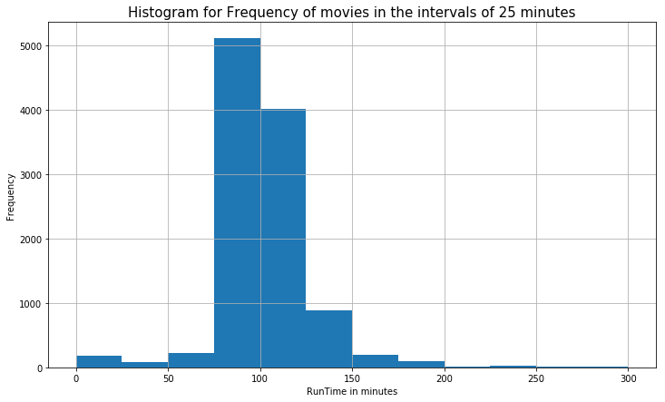

```python
bins = [x for x in range(0,301,25)]
#bins
movies_df['runtime'].hist(bins=bins,figsize = (12,7))
plt.xlabel('RunTime in minutes')
plt.ylabel('Frequency')
plt.title('Histogram for Frequency of movies in the intervals of 25 minutes',fontsize = 15)
```

- The histogram shows that the frequency of runtime is highest for 75 - 100 mins followed by 100 - 125 mins

**Ploting vote average for intervals of 25 mins from 0 mins to 300 mins from the runtime**

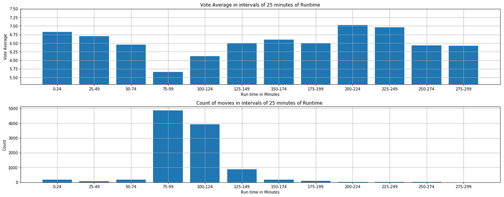

```python
#movies_df
list_count = []
list_avg = []
labels_run = []
for i in range(0,300,25):
    labels_run.append(str(i)+"-"+str(i+24))
    list_avg.append(movies_df[(movies_df.runtime >= i) & (movies_df.runtime < (i+24))]['vote_average'].mean())
    list_count.append(movies_df[(movies_df.runtime >= i) & (movies_df.runtime < (i+24))]['runtime'].count())

fig, [ax1,ax2] = plt.subplots(nrows=2, ncols=1,figsize=(18,7),constrained_layout=True)
ax1.bar(labels_run,list_avg,width = 0.8)
ax2.bar(labels_run,list_count,width = 0.8)
#https://chrisalbon.com/python/data_visualization/matplotlib_grouped_bar_plot/
#https://stackoverflow.com/questions/15858192/how-to-set-xlim-and-ylim-for-a-subplot-in-matplotlib
ax1.set_ylim([5.3,7.5])
#https://matplotlib.org/examples/pylab_examples/subplots_demo.html
ax1.set_ylabel('Vote Average'),ax1.set_xlabel('Run time in Minutes'),ax1.set_title("Vote Average in intervals of 25 minutes of Runtime")
ax1.grid(axis='both')
ax2.set_ylabel('Count'),ax2.set_xlabel('Run time in Minutes'),ax2.set_title("Count of movies in intervals of 25 minutes of Runtime ")
plt.grid()
plt.show()
```

- The count of movies with runtime between 75-99 mins have the highest count, but the vote average is the minimum falling below 5.7.
- The count for movies runtime between 100- 124 mins have the second highest count, but the average is second lowest 6.1
- Movies with runtime 0-24 mins,200-224 mins,225-249 mins have averages between 7 and 6.75

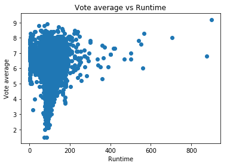

```python
plt.scatter(movies_df['runtime'],movies_df['vote_average'])
plt.xlabel('Runtime')
plt.ylabel('Vote average')
plt.title('Vote average vs Runtime')
plt.show()
```

##### Function **break_it** returns list of counts and vote averages for different time run intervals and year of n intervals

```python
def break_it(df,start,end,n):
    num = (end - start)//n + 1
    #print(num)

    labels,list_count,list_avg,list_count_y,list_avg_y = ([] for i in range(5))
    #print(years)
    if n == 1:
        #print("in 1" )
        for year in range(start,end+1):
            for i in range(0,300,25):

                list_avg.append(movies_df[(movies_df.release_year == year)&(movies_df.runtime >= i) & (movies_df.runtime < (i+24))]['vote_average'].mean())
                list_count.append(movies_df[(movies_df.release_year == year)&(movies_df.runtime >= i) & (movies_df.runtime < (i+24))]['runtime'].count())
            list_count_y.append(list_count)
            list_avg_y.append(list_avg)
            list_avg = []
            list_count = []
            labels.append(str(year))
    return(list_count_y,list_avg_y,labels)
```

##### ploting bar graph for vote average and movies count for runtime intervals of 25 minutes for the years 2011,2012,2013,2014,2015 and 2006,2007,2008,2009,2010

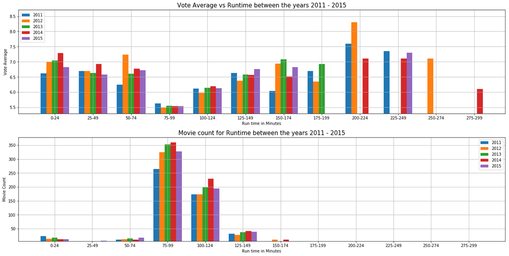

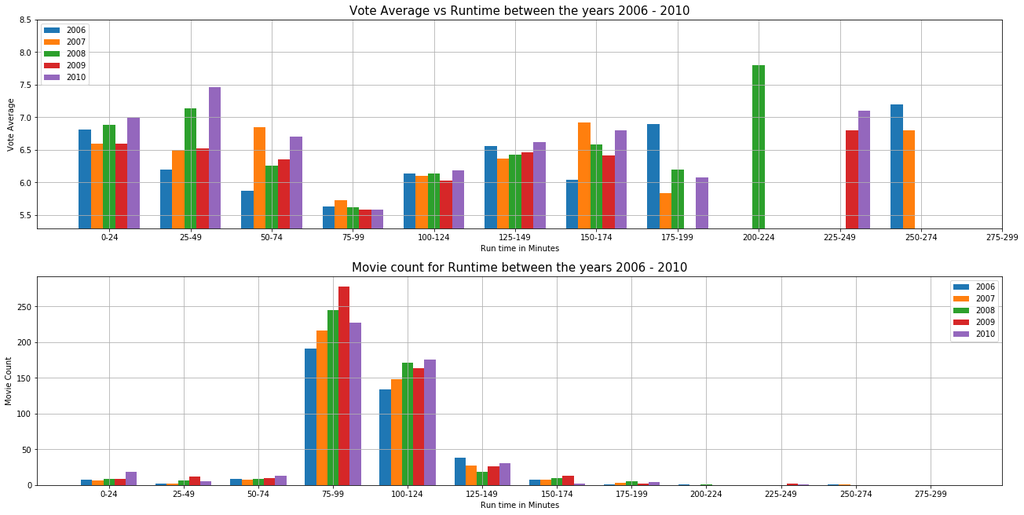

```
(None, None)
```

```python
list_count,list_avg,legends = break_it(movies_df,2011,2015,1)

fig, [ax1,ax2] = plt.subplots(nrows=2, ncols=1,figsize=(18,9),constrained_layout=True)
for i in range(0,5,1):
    ax1.bar(np.array(range(1,13,1)) + 0.15*(i-2) ,list_avg[i],width = 0.15)
    ax2.bar(np.array(range(1,13,1)) + 0.15*(i-2) ,list_count[i],width = 0.15)
#https://chrisalbon.com/python/data_visualization/matplotlib_grouped_bar_plot/
ax1.set_xticks(range(1,13,1)),ax1.set_xticklabels(labels_run),ax1.legend(legends),ax2.set_xticks(range(1,13,1)),ax2.set_xticklabels(labels_run)
ax1.set_ylim(5.3)
ax1.grid(axis='both')
ax2.legend(legends)
ax1.set_xlabel('Run time in Minutes'),ax2.set_xlabel('Run time in Minutes')
ax1.set_ylabel('Vote Average'),ax2.set_ylabel('Movie Count')
ax1.set_title('Vote Average vs Runtime between the years 2011 - 2015',fontsize = 15),ax2.set_title('Movie count for Runtime between the years 2011 - 2015',fontsize = 15)
#plt.yticks(np.linspace(5, 6.7, 10))
#https://matplotlib.org/api/_as_gen/matplotlib.pyplot.ylim.html
plt.ylim(bottom=5.3),plt.grid(),plt.show()

list_count2,list_avg2,legends2 = break_it(movies_df,2006,2010,1)
fig, [ax1,ax2] = plt.subplots(nrows=2, ncols=1,figsize=(18,9),constrained_layout=True)
for i in range(0,5,1):
    ax1.bar(np.array(range(1,13,1)) + 0.15*(i-2) ,list_avg2[i],width = 0.15)
    ax2.bar(np.array(range(1,13,1)) + 0.15*(i-2) ,list_count2[i],width = 0.15)
#https://chrisalbon.com/python/data_visualization/matplotlib_grouped_bar_plot/
ax1.set_ylim([5.3,8.5])
ax1.set_ylim(5.3)
ax1.grid(axis='both')
ax1.legend(legends2)
ax1.set_xticks(range(1,13,1)),ax1.set_xticklabels(labels_run),ax2.set_xticks(range(1,13,1)),ax2.set_xticklabels(labels_run)
ax2.legend(legends2)
ax1.set_xlabel('Run time in Minutes'),ax2.set_xlabel('Run time in Minutes')
ax1.set_ylabel('Vote Average'),ax2.set_ylabel('Movie Count')
ax1.set_title('Vote Average vs Runtime between the years 2006 - 2010',fontsize = 15)
ax2.set_title('Movie count for Runtime between the years 2006 - 2010',fontsize = 15)
#https://matplotlib.org/api/_as_gen/matplotlib.pyplot.ylim.html
#plt.ylim(bottom=5.3)
plt.grid(),plt.show()
```

- The count of movies with runtime 200-224 is almost zero and zeros for many years from 2006 -2015 which has an overall highest vote average of 7 from the previous plot.
- Vote average has decreases for 0-24mins runtime movies in the year 2015
- The vote average for 75-99mins runtime movie is consistant near 5.5
- 2008,11,12,14 has shown vote avergae above 7

## Limitations:

> **Insufficient Data**:
> - The movie languages of the movie is not provided for better analysis.
> - The Revenue and Budject data are missing for more than 40% of the rows, hence **could not do statistical analysis on budget and average corelation.**
> - Many budget and revenue coulumn has value 0

> **Missing Data**:
> - 76 cast,23 genres are missing and 1493 keywords are missing these can not be filled with any statistical values because they are not strings. **Statistical calculation on genres will not be accurate for this test**

> **Unsure Column meaning**: Did not know how to implement popularity as the scale of popularity was not none.

## Conclusions

> **Vote average and Genres**: The can be seen that has very little corelation with genres of the movie. The counts of the genres were not the same and the counts of certain genres such as Drama and comedy were a lot more than the rest of the genres. Documentry movies have the highest vote averages but the counts are significantly less than other genres.

> **Vote Average and release month**: there is some corelation between the vote average and movie realsed in a particular quarters.The statistis performed is not sufficient to strongly corelate release month and the vote average of the movie

> **Vote Average and runtime**: There is very little corelation between vote average and runtime as the function corr() suggested. The plots showed a rise and fall of vote avergage from 0 - 99mins and again climbing from 100mins to 224mins. The data for movies with runtime more than 300 mins is very less to find a relation between vote average of movies more than 300 mins.